# TACTIC-R Simulation

Simon Bond

01 Jun 2020

# Creating Data

We define some functions to simulate failure time data, which is discretized to days, 1,2,..14. Plus adding in some censoring at day 14, or earlier with a given dropout rate. There is also a site level random interecept on the log hazard scale.

```r
sim_failure <- function(n_per_arm, control_surv_rate, hr, site_raneff_sd=0.1, last_time=14){
  require(magrittr)
  #set parameters
  n_arms <- length(hr)+1
  rx <- rep(1:n_arms, rep(n_per_arm,n_arms)) %>%
    factor(labels=c("Cx",paste0("E",1:(n_arms-1))))
  #lazy replication
  site <- rep(1, length(rx))
  site[1:length(site)] <- 1:10
  site_re <- rnorm(n=10,mean=0, sd=site_raneff_sd)
  #assume exponential distribution
  hazard_cx <-   -log(control_surv_rate)/last_time
  hazard <- hazard_cx*c(1,hr)
  time_exact <- rexp(length(rx),rate=hazard[rx %>% as.numeric]*exp(site_re[site]))
  time <- pmin(ceiling(time_exact), last_time)
  status <- 1*(time_exact<last_time)
  data.frame(rx, time, status, time_exact,site)
}

add_censor <- function(data, admin_cens_time, drop_out, drop_out_time=max(admin_cens_time)){
  haz <-  -log(1-drop_out)/drop_out_time
  n <- nrow(data)
  cens <- rexp(n, rate=haz)
  cens <- pmin(cens, admin_cens_time)
  time_exact <- pmin(data$time_exact, cens)
  status <- ifelse( cens<data$time_exact, 0, data$status)
  time <-  ceiling(time_exact)
  data$time <- time
  data$status <- status
  data$cens <- cens
  data
}

#test
if(FALSE){
  df <- sim_failure(n_per_arm = 1000,control_surv_rate = 0.7, hr=c(0.7,1.3)) %>%
    add_censor(admin_cens_time = 14, drop_out=0.1)
  survfit(Surv(time, status)~rx,data=df) %>% plot(mark.time=TRUE,lty=1:3)
  coxph(Surv(time, status)~rx,data=df) %>% summary
#check the censoring.
  survfit(Surv(time,1-status)~1, data=df) %>% plot
  abline(h=0.9)
}
df <- sim_failure(n_per_arm = 125,control_surv_rate = 0.7, hr=c(0.7,1.3)) %>%
  add_censor(admin_cens_time = 14, drop_out=0.1)

#add in site , Any other covars?
#df$site <- rep(1:25,nrow(df)/25) %>% factor


# surv_split the data

fail_times <- df %>% filter(status==1) %>% select(time) %>% unique() %>% unlist
df_long <- survSplit(Surv(time, status)~rx+site, df, cut=fail_times)
```

So assume n=125 per arm, 3 arm with HR of 0.7 and 1.3. Site log Haz SD=0.1, and assuming 30% event rate in teh control arm at day 14.

```r
df <- sim_failure(n_per_arm = 125,control_surv_rate = 0.7, hr=c(0.7,1.3), site_raneff_sd = 0.1) %>%
  add_censor(admin_cens_time = 14, drop_out=0.1)
kable(df) %>% kable_styling() %>% scroll_box(height="200px")
```

| rx | time | status | time_exact | site | cens |
| --- | --- | --- | --- | --- | --- |
| Cx | 14 | 0 | 49.2873805 | 1 | 14.0000000 |
| Cx | 5 | 1 | 4.0308992 | 2 | 14.0000000 |
| Cx | 5 | 1 | 4.0947573 | 3 | 14.0000000 |
| Cx | 1 | 0 | 12.2679423 | 4 | 0.3297010 |
| Cx | 14 | 0 | 31.3978675 | 5 | 14.0000000 |
| Cx | 5 | 0 | 33.1346307 | 6 | 4.5250520 |
| Cx | 14 | 0 | 21.2470049 | 7 | 14.0000000 |
| Cx | 3 | 1 | 2.2632233 | 8 | 14.0000000 |
| Cx | 14 | 0 | 59.4377149 | 9 | 14.0000000 |
| Cx | 14 | 0 | 35.5272963 | 10 | 14.0000000 |
| Cx | 6 | 1 | 5.6352329 | 1 | 14.0000000 |
| Cx | 14 | 0 | 41.5323898 | 2 | 14.0000000 |
| Cx | 1 | 0 | 79.6952172 | 3 | 0.2680834 |
| Cx | 14 | 0 | 42.7704683 | 4 | 14.0000000 |
| Cx | 14 | 0 | 32.7777330 | 5 | 14.0000000 |
| Cx | 2 | 1 | 1.8218261 | 6 | 14.0000000 |
| Cx | 14 | 0 | 42.2517796 | 7 | 14.0000000 |
| Cx | 14 | 0 | 93.0779532 | 8 | 14.0000000 |
| Cx | 14 | 0 | 32.2283627 | 9 | 14.0000000 |
| Cx | 14 | 0 | 37.0613567 | 10 | 14.0000000 |
| Cx | 14 | 0 | 15.3572602 | 1 | 14.0000000 |
| Cx | 14 | 0 | 84.1018649 | 2 | 14.0000000 |
| Cx | 11 | 1 | 10.8949234 | 3 | 14.0000000 |
| Cx | 5 | 1 | 4.6568342 | 4 | 6.7220072 |
| Cx | 6 | 1 | 5.3659152 | 5 | 14.0000000 |
| Cx | 14 | 0 | 23.7224175 | 6 | 14.0000000 |
| Cx | 14 | 0 | 26.6346964 | 7 | 14.0000000 |
| Cx | 14 | 0 | 82.7979434 | 8 | 14.0000000 |
| Cx | 14 | 0 | 36.2349498 | 9 | 14.0000000 |
| Cx | 14 | 0 | 17.7852341 | 10 | 14.0000000 |

[output cut: 345 more lines]

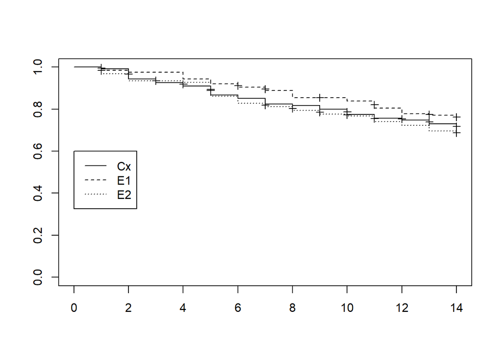

```r
survfit(Surv(time,status)~rx, data=df) %>% plot(lty=1:3, mark.time=TRUE)
legend(0,0.6,lty=1:3, legend=levels(df$rx))
```

# Digression into the Poisson trick

Any Cox Ph model can also be fitted using a GLM with a poisson distribution, if the individual patient history is broken up into individual time segments, and the dependent variable is an indicator as to whether they failed. The likelihoods coincide exactly, as the dependent variable only takes values 0 and 1. The latter can easily be implimented in Bayesian MCMC models/tools, but there is no readily available mapping directly to CoxPH. Alternative Bayes methods use a flexibility parametric smoothing approach to estimate the baseline hazard. But given that there are only 14 days, this is not required, and the implimentation is far more robust to use a GLM/Poisson model via the [rstanarm pacakge](https://mc-stan.org/rstanarm/) .

The match to within computing arithmetic accuracy in the fixed effects model, and when the random effects are added in, with different methods of quadrature, then they are practically identical.

```r
fail_times <- df %>% filter(status==1) %>% select(time) %>% unique() %>% unlist
df_long <- survSplit(Surv(time, status)~rx+site, df, cut=fail_times)
glm(status~-1+strata(time)+rx , family=poisson, data=df_long) %>% summary
```

```
##
## Call:
## glm(formula = status ~ -1 + strata(time) + rx, family = poisson,
##     data = df_long)
##
## Deviance Residuals:
##     Min       1Q   Median       3Q      Max
## -0.3290  -0.2318  -0.2158  -0.1931   2.8760
##
## Coefficients:
##                     Estimate Std. Error z value Pr(>|z|)
## strata(time)time=1  -3.94677    0.40180  -9.823  < 2e-16 ***
## strata(time)time=2  -3.46334    0.33068 -10.473  < 2e-16 ***
## strata(time)time=3  -5.12974    0.72042  -7.120 1.08e-12 ***
## strata(time)time=4  -3.86476    0.40267  -9.598  < 2e-16 ***
## strata(time)time=5  -3.01602    0.28617 -10.539  < 2e-16 ***
## strata(time)time=6  -3.64783    0.37988  -9.603  < 2e-16 ***
## strata(time)time=7  -3.75229    0.40248  -9.323  < 2e-16 ***
## strata(time)time=8  -3.71612    0.40234  -9.236  < 2e-16 ***
## strata(time)time=9  -4.24936    0.51837  -8.197 2.45e-16 ***
## strata(time)time=10 -3.81895    0.43047  -8.872  < 2e-16 ***
## strata(time)time=11 -3.38038    0.36049  -9.377  < 2e-16 ***
## strata(time)time=12 -3.74263    0.43023  -8.699  < 2e-16 ***
## strata(time)time=13 -3.71625    0.43015  -8.639  < 2e-16 ***
## strata(time)time=14 -3.52954    0.40160  -8.789  < 2e-16 ***
## rxE1                -0.22997    0.24883  -0.924    0.355
## rxE2                 0.09933    0.23431   0.424    0.672
## ---
## Signif. codes:  0 '***' 0.001 '**' 0.01 '*' 0.05 '.' 0.1 ' ' 1
##
## (Dispersion parameter for poisson family taken to be 1)
##
##     Null deviance: 8454.00  on 4330  degrees of freedom
## Residual deviance:  751.35  on 4314  degrees of freedom
## AIC: 989.35
##
## Number of Fisher Scoring iterations: 7
```

```r
coxph(Surv(time,status)~rx, data=df, ties = "breslow") %>% summary
```

```
## Call:
## coxph(formula = Surv(time, status) ~ rx, data = df, ties = "breslow")
##
##   n= 375, number of events= 103
##
##          coef exp(coef) se(coef)      z Pr(>|z|)
## rxE1 -0.22997   0.79456  0.24883 -0.924    0.355
## rxE2  0.09933   1.10443  0.23431  0.424    0.672
##
##      exp(coef) exp(-coef) lower .95 upper .95
## rxE1    0.7946     1.2586    0.4879     1.294
## rxE2    1.1044     0.9054    0.6977     1.748
##
## Concordance= 0.54  (se = 0.027 )
## Likelihood ratio test= 1.91  on 2 df,   p=0.4
## Wald test            = 1.87  on 2 df,   p=0.4
## Score (logrank) test = 1.88  on 2 df,   p=0.4
```

```r
glmer(status~-1+strata(time)+rx +(1|site), family=poisson, data=df_long) %>% summary
```

```
## boundary (singular) fit: see ?isSingular
```

```
## Generalized linear mixed model fit by maximum likelihood (Laplace
##   Approximation) [glmerMod]
##  Family: poisson  ( log )
## Formula: status ~ -1 + strata(time) + rx + (1 | site)
##    Data: df_long
##
##      AIC      BIC   logLik deviance df.resid
##    991.3   1099.7   -478.7    957.3     4313
##
## Scaled residuals:
##     Min      1Q  Median      3Q     Max
## -0.2326 -0.1639 -0.1526 -0.1365 12.9220
##
## Random effects:
##  Groups Name        Variance Std.Dev.
##  site   (Intercept) 4e-14    2e-07
## Number of obs: 4330, groups:  site, 10
##
## Fixed effects:
##                     Estimate Std. Error z value Pr(>|z|)
## strata(time)time=1  -3.94677    0.40179  -9.823  < 2e-16 ***
## strata(time)time=2  -3.46334    0.33068 -10.473  < 2e-16 ***
## strata(time)time=3  -5.12974    0.72024  -7.122 1.06e-12 ***
## strata(time)time=4  -3.86476    0.40269  -9.597  < 2e-16 ***
## strata(time)time=5  -3.01602    0.28616 -10.539  < 2e-16 ***
## strata(time)time=6  -3.64783    0.37987  -9.603  < 2e-16 ***
## strata(time)time=7  -3.75229    0.40248  -9.323  < 2e-16 ***
## strata(time)time=8  -3.71612    0.40232  -9.237  < 2e-16 ***
## strata(time)time=9  -4.24936    0.51839  -8.197 2.46e-16 ***
## strata(time)time=10 -3.81895    0.43045  -8.872  < 2e-16 ***
## strata(time)time=11 -3.38038    0.36049  -9.377  < 2e-16 ***
## strata(time)time=12 -3.74263    0.43024  -8.699  < 2e-16 ***
## strata(time)time=13 -3.71625    0.43013  -8.640  < 2e-16 ***
## strata(time)time=14 -3.52954    0.40160  -8.789  < 2e-16 ***
## rxE1                -0.22997    0.24883  -0.924    0.355
## rxE2                 0.09933    0.23430   0.424    0.672
## ---
## Signif. codes:  0 '***' 0.001 '**' 0.01 '*' 0.05 '.' 0.1 ' ' 1
```

```
##
## Correlation matrix not shown by default, as p = 16 > 12.
## Use print(x, correlation=TRUE)  or
##     vcov(x)        if you need it
```

```
## convergence code: 0
## boundary (singular) fit: see ?isSingular
```

```r
coxph(Surv(time,status)~rx+frailty.gaussian(site), data=df, ties = "breslow") %>% summary
```

[output not shown]

# Bayesian version thereof

First I set some priors. These are defined by providing 5% and 95% quantiles, or 50% and 5/95% for the baseline hazard and hazard ratios, and then converting the quantiles to match up with a normal distribution. Currently the prior for the random effects uses the default option provide, which is likely to be too diffuse.

- baseline hazard: between 0.05 and 0.95 increment in cumulative hazard of failure in each day.
- Vague HR between 0.3 and 3.33. Equivalent to trial with 7 events
- Optimistic HR centred on 0.7, with 95% quantile at 1, equivlaent to 85-event trial.
- Pessimistic HR centred on 1 with 5% quantile at 0.7, equivalent to 85-event trial.

```r
library(rstanarm)
#library(brms)
options(mc.cores = parallel::detectCores())
library(bayesplot)
#theme_set(bayesplot::theme_default())
inverse_normal <- function(quantiles, probs=c(0.05,0.95)){
  A <- cbind(1,qnorm(probs))
  ans <- solve(A, quantiles)
  names(ans) <- c("location","scale")
  ans
}

#test
# inverse_normal(c(-1,2))
# pnorm(c(-1,2),mean=0.5, sd=0.9119)

#control hazard function

# set of cumhaz increments per day for days 1- 14
# if exponential with 14-day survival S0, then log-haz= log(-ln(1-S0)/14)

(quantile_log_haz <- log(-log(c(0.95,0.05))/14))
(base_log_haz_pars <- inverse_normal(quantile_log_haz))

(log_hr <- inverse_normal(log(c(0.3,1/0.3))))

#number of events in a 2 arm trial
4/log_hr["scale"]^2 # 7


vague <- normal(location=rep( c(base_log_haz_pars["location"], log_hr["location"]), c(14,2)),
                scale=rep( c(base_log_haz_pars["scale"], log_hr["scale"]), c(14,2)),
                autoscale=FALSE
                )

#optimistic
(log_hr <- inverse_normal(log(c(0.7,1)), probs=c(0.5,0.95)))

#number of events in a 2 arm trial
4/log_hr["scale"]^2 # 85

optimistic <- normal(location=rep( c(base_log_haz_pars["location"], log_hr["location"]), c(14,2)),
                scale=rep( c(base_log_haz_pars["scale"], log_hr["scale"]), c(14,2)),
                autoscale=FALSE
)


#pessimistic
(log_hr <- inverse_normal(log(c(0.7,1)), probs=c(0.05,0.5)))

#number of events in a 2 arm trial
4/log_hr["scale"]^2 # 85

pessimistic <- normal(location=rep( c(base_log_haz_pars["location"], log_hr["location"]), c(14,2)),
                    scale=rep( c(base_log_haz_pars["scale"], log_hr["scale"]), c(14,2)),
                    autoscale=FALSE
)
prior_list <- list("vague"=vague, "optimistic"=optimistic, "pessimistic"=pessimistic)
effects <- c("rxE1","rxE2")
```

Now we use the rstan and rstanarm to impliment MCMM regression, in the case of a vague prior first.

```r
# fits <- lapply(prior_list,
#                  function(my_prior){
#                    stan_glmer(status~-1+strata(time)+rx+(1|site), data=df_long, family=poisson,
#                             chains=2, iter=1000,QR=FALSE, thin=2,
#                             prior =my_prior)
#                  }
#   )

fits <- foreach(i = 1:length(prior_list),
                .inorder = TRUE,
                .packages=c("rstanarm","survival"),
                .export=c("df_long")
                ) %dopar% {
  stan_glmer(status~-1+strata(time)+rx+(1|site), data=df_long, family=poisson,
                            chains=2, iter=2000,QR=FALSE, thin=2,
                            prior =prior_list[[i]])
}
names(fits) <- names(prior_list)

output <- NULL
for( index  in 1:length(fits)){
  output <- c(output, knit_child("reporting_on_model.Rmd"))
}
```

## Prior: vague

```r
fit <- fits[[index]]
fit %>% summary
```

```
##
## Model Info:
##  function:     stan_glmer
##  family:       poisson [log]
##  formula:      status ~ -1 + strata(time) + rx + (1 | site)
##  algorithm:    sampling
##  sample:       1000 (posterior sample size)
##  priors:       see help('prior_summary')
##  observations: 4330
##  groups:       site (10)
##
## Estimates:
##                                       mean   sd   10%   50%   90%
## strata(time)time=1                  -3.9    0.4 -4.5  -3.9  -3.5
## strata(time)time=2                  -3.5    0.3 -4.0  -3.5  -3.1
## strata(time)time=3                  -4.9    0.6 -5.6  -4.9  -4.2
## strata(time)time=4                  -3.9    0.4 -4.4  -3.8  -3.4
## strata(time)time=5                  -3.0    0.3 -3.4  -3.0  -2.7
## strata(time)time=6                  -3.7    0.4 -4.2  -3.7  -3.2
## strata(time)time=7                  -3.8    0.4 -4.3  -3.7  -3.3
## strata(time)time=8                  -3.7    0.4 -4.2  -3.7  -3.3
## strata(time)time=9                  -4.2    0.5 -4.8  -4.2  -3.7
## strata(time)time=10                 -3.8    0.4 -4.4  -3.8  -3.4
## strata(time)time=11                 -3.4    0.3 -3.9  -3.4  -3.0
## strata(time)time=12                 -3.8    0.4 -4.3  -3.8  -3.2
## strata(time)time=13                 -3.8    0.4 -4.3  -3.7  -3.2
## strata(time)time=14                 -3.6    0.4 -4.1  -3.6  -3.1
## rxE1                                -0.3    0.2 -0.6  -0.3   0.0
## rxE2                                 0.0    0.2 -0.2   0.0   0.3
## b[(Intercept) site:1]               -0.1    0.2 -0.3   0.0   0.1
## b[(Intercept) site:2]                0.0    0.2 -0.1   0.0   0.3
## b[(Intercept) site:3]                0.0    0.2 -0.2   0.0   0.1
## b[(Intercept) site:4]                0.0    0.2 -0.2   0.0   0.1
## b[(Intercept) site:5]                0.0    0.1 -0.2   0.0   0.2
## b[(Intercept) site:6]                0.0    0.2 -0.2   0.0   0.1
## b[(Intercept) site:7]                0.1    0.2  0.0   0.1   0.4
## b[(Intercept) site:8]                0.1    0.2 -0.1   0.0   0.3
## b[(Intercept) site:9]               -0.1    0.2 -0.4  -0.1   0.1
## b[(Intercept) site:10]               0.0    0.2 -0.2   0.0   0.2
## Sigma[site:(Intercept),(Intercept)]  0.0    0.1  0.0   0.0   0.1
```

[output cut: 25 more lines]

```
## b[(Intercept) site:1]               0.0  1.0  896
## b[(Intercept) site:2]               0.0  1.0  885
## b[(Intercept) site:3]               0.0  1.0  811
## b[(Intercept) site:4]               0.0  1.0  887
## b[(Intercept) site:5]               0.0  1.0  814
## b[(Intercept) site:6]               0.0  1.0  618
## b[(Intercept) site:7]               0.0  1.0  835
## b[(Intercept) site:8]               0.0  1.0  824
## b[(Intercept) site:9]               0.0  1.0  648
## b[(Intercept) site:10]              0.0  1.0  867
## Sigma[site:(Intercept),(Intercept)] 0.0  1.0  795
## mean_PPD                            0.0  1.0  852
## log-posterior                       0.2  1.0  666
##
## For each parameter, mcse is Monte Carlo standard error, n_eff is a crude measure of effective sample size, and Rhat is the potential scale reduction factor on split chains (at convergence Rhat=1).
```

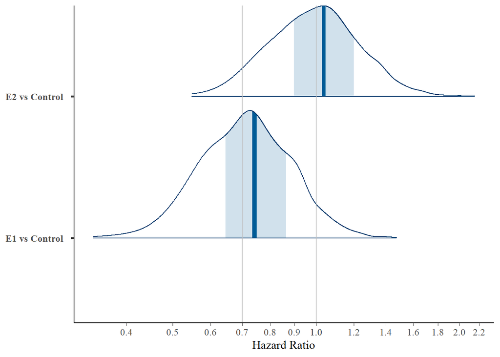

```r
plot(fit, pars=effects, plotfun = "areas", transformations="exp")+
  labs(x="Hazard Ratio")+scale_y_discrete(labels=c("E1 vs Control  ","E2 vs Control  "))+
  scale_x_log10(breaks=c(seq(0.4,1,by=0.1),seq(1,3,by=0.2)))+geom_vline(xintercept=c(0.7,1), col="grey")
```

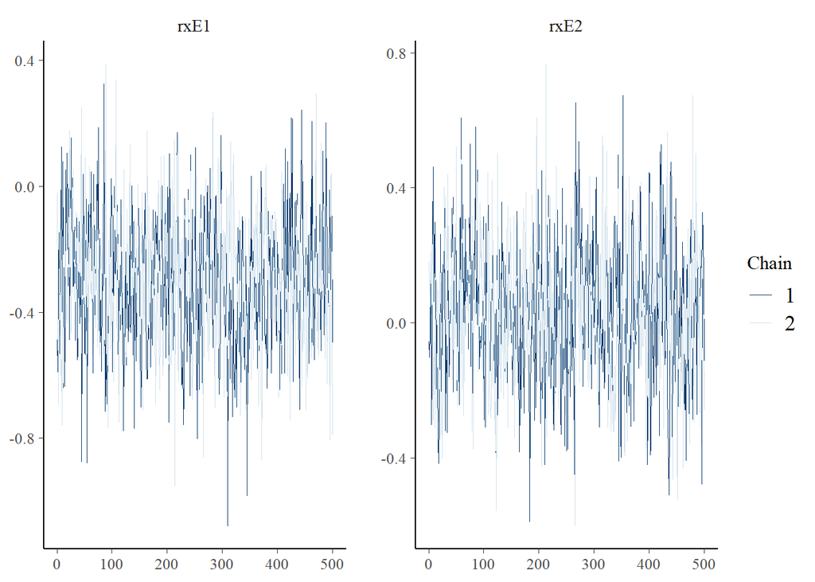

```r
#plot(fit, pars=effects, "hist")
#plot(fit, pars=effects, "violin")
#plot(fit, pars=effects, "dens_overlay")
plot(fit, pars=effects, "trace")
```

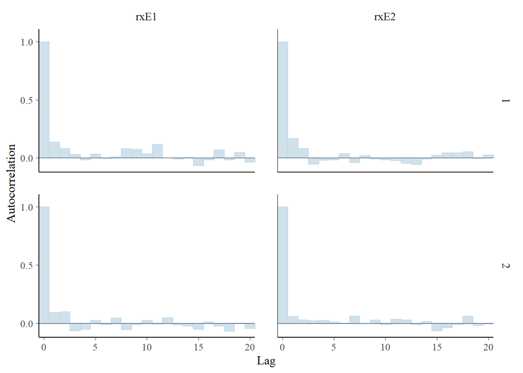

```r
plot(fit, pars=effects, "acf_bar")
```

```r
posterior <- as.array(fit)
#dimnames(posterior)

prob_interval <- function(X, interval){
  Y <- interval[1]< X & X <interval[2]
  mean(Y)
}
efficacy <- apply(posterior, 3, FUN=prob_interval, interval=c(-Inf, 0))[effects]
moderate_efficacy <- apply(posterior, 3, FUN=prob_interval, interval=c(-Inf, log(0.8)))[effects]
similarity <- apply(posterior, 3, FUN=prob_interval, interval= log(c(0.8,1.25)))[effects]
harm <- apply(posterior, 3, FUN=prob_interval, interval= c(0,Inf))[effects]
```

Reporting as per section 15.2 of the protocol to give the posterior probability of the HR lieing in various ranges of interest.

```r
X <- rbind(efficacy, moderate_efficacy, similarity, harm) %>% as.data.frame
X <- cbind(HR=c("<1","<0.8","0.8-1.25",">1"),X)
X %>% kable(row.names=FALSE, col.names=c("HR","E1 vs Control  ", "E2 vs Control  "))
```

| HR | E1 vs Control | E2 vs Control |
| --- | --- | --- |
| <1 | 0.918 | 0.425 |
| <0.8 | 0.629 | 0.119 |
| 0.8-1.25 | 0.364 | 0.693 |
| >1 | 0.082 | 0.575 |

## Prior: optimistic

```r
fit <- fits[[index]]
fit %>% summary
```

```
##
## Model Info:
##  function:     stan_glmer
##  family:       poisson [log]
##  formula:      status ~ -1 + strata(time) + rx + (1 | site)
##  algorithm:    sampling
##  sample:       1000 (posterior sample size)
##  priors:       see help('prior_summary')
##  observations: 4330
##  groups:       site (10)
##
## Estimates:
##                                       mean   sd   10%   50%   90%
## strata(time)time=1                  -3.9    0.4 -4.4  -3.9  -3.4
## strata(time)time=2                  -3.4    0.3 -3.8  -3.4  -3.0
## strata(time)time=3                  -4.8    0.5 -5.6  -4.8  -4.1
## strata(time)time=4                  -3.8    0.4 -4.3  -3.8  -3.3
## strata(time)time=5                  -2.9    0.3 -3.3  -2.9  -2.6
## strata(time)time=6                  -3.6    0.4 -4.0  -3.5  -3.1
## strata(time)time=7                  -3.7    0.4 -4.1  -3.6  -3.2
## strata(time)time=8                  -3.6    0.4 -4.1  -3.6  -3.2
## strata(time)time=9                  -4.1    0.5 -4.8  -4.1  -3.6
## strata(time)time=10                 -3.8    0.4 -4.3  -3.7  -3.2
## strata(time)time=11                 -3.3    0.4 -3.8  -3.3  -2.9
## strata(time)time=12                 -3.7    0.4 -4.2  -3.6  -3.2
## strata(time)time=13                 -3.7    0.4 -4.2  -3.6  -3.2
## strata(time)time=14                 -3.5    0.4 -4.0  -3.5  -3.0
## rxE1                                -0.4    0.2 -0.6  -0.4  -0.2
## rxE2                                -0.2    0.2 -0.3  -0.2   0.0
## b[(Intercept) site:1]               -0.1    0.2 -0.3   0.0   0.1
## b[(Intercept) site:2]                0.0    0.2 -0.1   0.0   0.3
## b[(Intercept) site:3]                0.0    0.2 -0.2   0.0   0.1
## b[(Intercept) site:4]                0.0    0.2 -0.2   0.0   0.1
## b[(Intercept) site:5]                0.0    0.2 -0.2   0.0   0.2
## b[(Intercept) site:6]                0.0    0.2 -0.3   0.0   0.1
## b[(Intercept) site:7]                0.1    0.2  0.0   0.1   0.4
## b[(Intercept) site:8]                0.1    0.2 -0.1   0.0   0.3
## b[(Intercept) site:9]               -0.1    0.2 -0.4  -0.1   0.1
## b[(Intercept) site:10]               0.0    0.2 -0.2   0.0   0.2
## Sigma[site:(Intercept),(Intercept)]  0.0    0.1  0.0   0.0   0.1
```

[output cut: 25 more lines]

```
## b[(Intercept) site:1]               0.0  1.0  856
## b[(Intercept) site:2]               0.0  1.0  901
## b[(Intercept) site:3]               0.0  1.0  856
## b[(Intercept) site:4]               0.0  1.0  795
## b[(Intercept) site:5]               0.0  1.0  884
## b[(Intercept) site:6]               0.0  1.0  898
## b[(Intercept) site:7]               0.0  1.0  781
## b[(Intercept) site:8]               0.0  1.0  917
## b[(Intercept) site:9]               0.0  1.0  813
## b[(Intercept) site:10]              0.0  1.0  822
## Sigma[site:(Intercept),(Intercept)] 0.0  1.0  891
## mean_PPD                            0.0  1.0  902
## log-posterior                       0.2  1.0  637
##
## For each parameter, mcse is Monte Carlo standard error, n_eff is a crude measure of effective sample size, and Rhat is the potential scale reduction factor on split chains (at convergence Rhat=1).
```

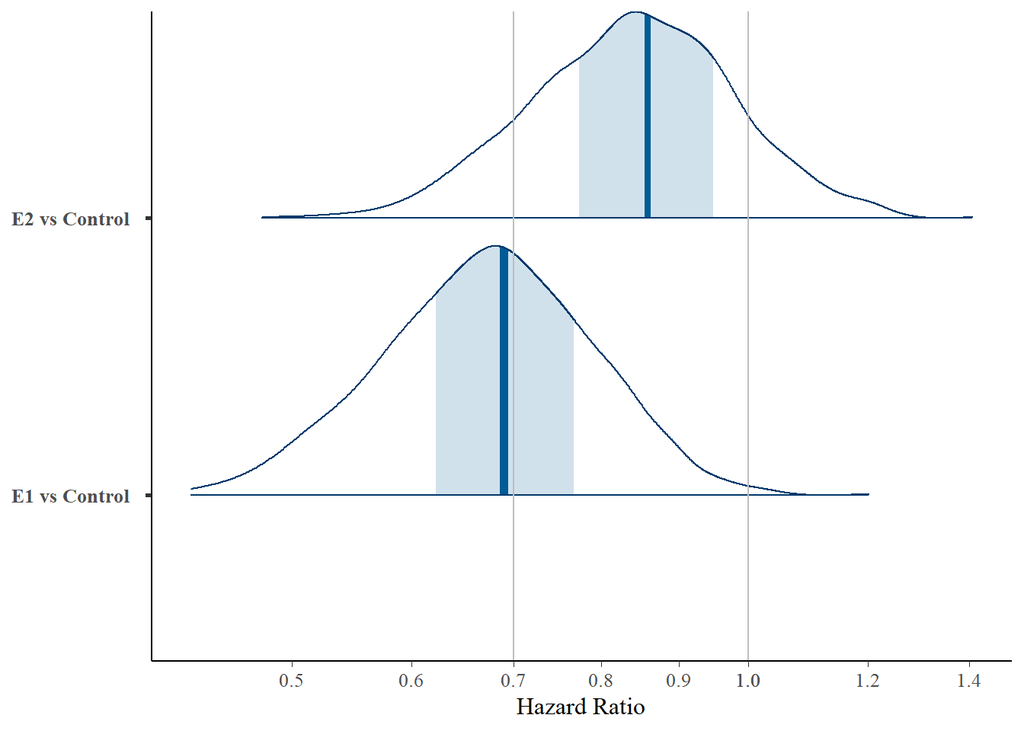

```r
plot(fit, pars=effects, plotfun = "areas", transformations="exp")+
  labs(x="Hazard Ratio")+scale_y_discrete(labels=c("E1 vs Control  ","E2 vs Control  "))+
  scale_x_log10(breaks=c(seq(0.4,1,by=0.1),seq(1,3,by=0.2)))+geom_vline(xintercept=c(0.7,1), col="grey")
```

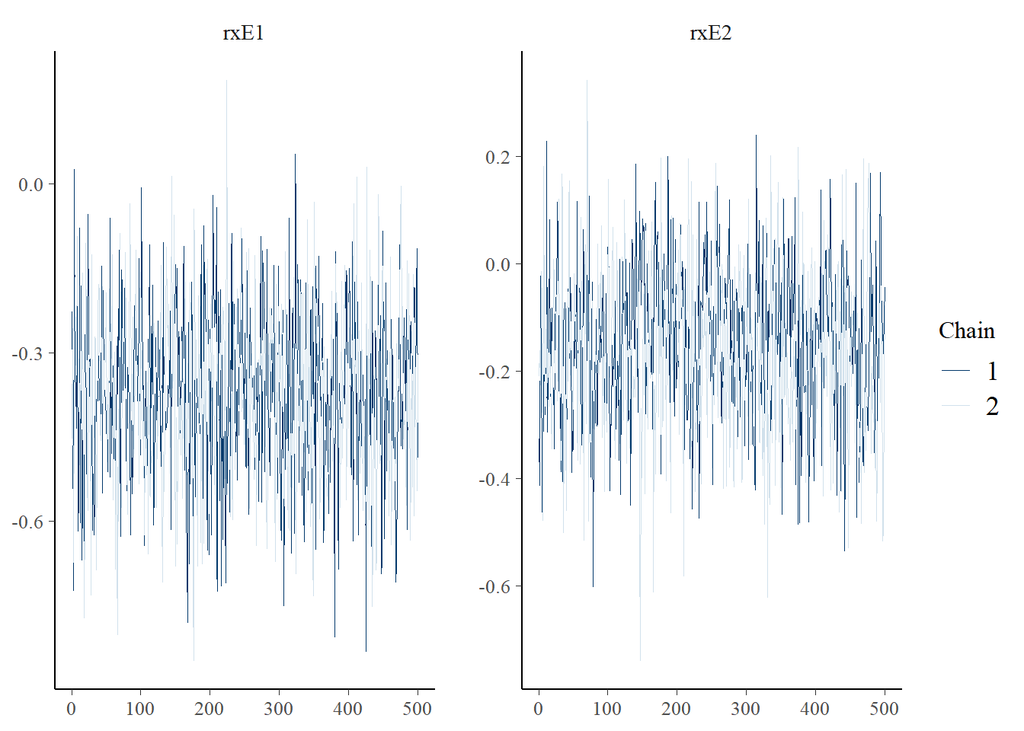

```r
#plot(fit, pars=effects, "hist")
#plot(fit, pars=effects, "violin")
#plot(fit, pars=effects, "dens_overlay")
plot(fit, pars=effects, "trace")
```

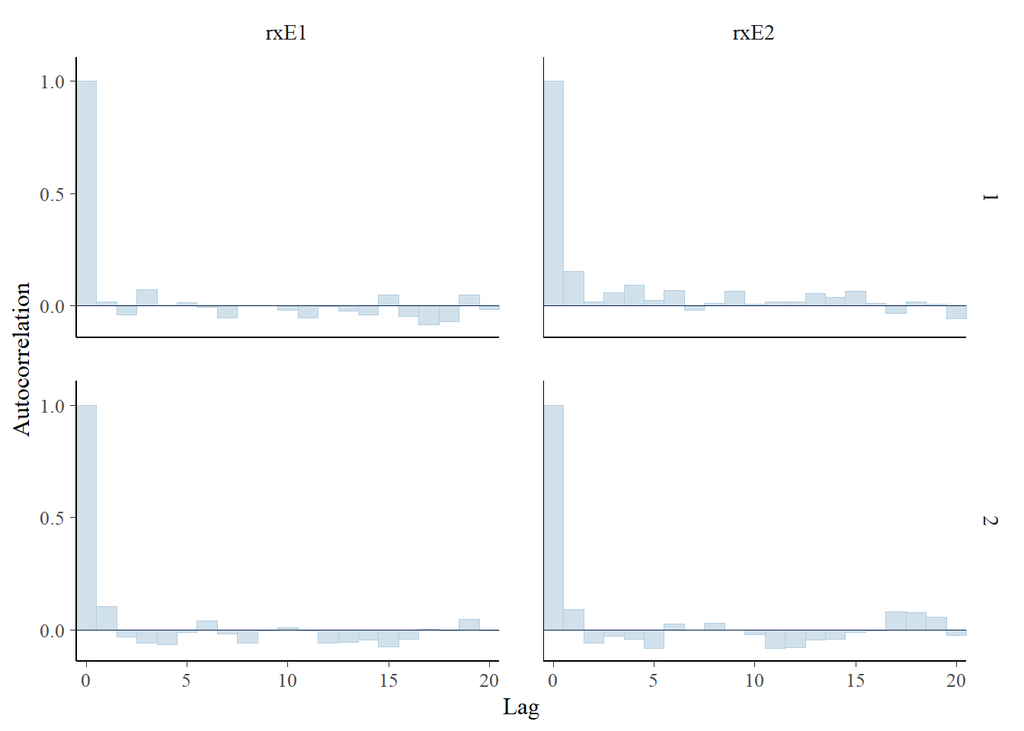

```r
plot(fit, pars=effects, "acf_bar")
```

```r
posterior <- as.array(fit)
#dimnames(posterior)

prob_interval <- function(X, interval){
  Y <- interval[1]< X & X <interval[2]
  mean(Y)
}
efficacy <- apply(posterior, 3, FUN=prob_interval, interval=c(-Inf, 0))[effects]
moderate_efficacy <- apply(posterior, 3, FUN=prob_interval, interval=c(-Inf, log(0.8)))[effects]
similarity <- apply(posterior, 3, FUN=prob_interval, interval= log(c(0.8,1.25)))[effects]
harm <- apply(posterior, 3, FUN=prob_interval, interval= c(0,Inf))[effects]
```

Reporting as per section 15.2 of the protocol to give the posterior probability of the HR lieing in various ranges of interest.

```r
X <- rbind(efficacy, moderate_efficacy, similarity, harm) %>% as.data.frame
X <- cbind(HR=c("<1","<0.8","0.8-1.25",">1"),X)
X %>% kable(row.names=FALSE, col.names=c("HR","E1 vs Control  ", "E2 vs Control  "))
```

| HR | E1 vs Control | E2 vs Control |
| --- | --- | --- |
| <1 | 0.994 | 0.850 |
| <0.8 | 0.820 | 0.304 |
| 0.8-1.25 | 0.180 | 0.693 |
| >1 | 0.006 | 0.150 |

## Prior: pessimistic

```r
fit <- fits[[index]]
fit %>% summary
```

```
##
## Model Info:
##  function:     stan_glmer
##  family:       poisson [log]
##  formula:      status ~ -1 + strata(time) + rx + (1 | site)
##  algorithm:    sampling
##  sample:       1000 (posterior sample size)
##  priors:       see help('prior_summary')
##  observations: 4330
##  groups:       site (10)
##
## Estimates:
##                                       mean   sd   10%   50%   90%
## strata(time)time=1                  -4.0    0.4 -4.5  -4.0  -3.5
## strata(time)time=2                  -3.5    0.3 -3.9  -3.5  -3.2
## strata(time)time=3                  -4.9    0.6 -5.7  -4.9  -4.2
## strata(time)time=4                  -3.9    0.4 -4.4  -3.9  -3.5
## strata(time)time=5                  -3.1    0.3 -3.4  -3.1  -2.7
## strata(time)time=6                  -3.7    0.3 -4.1  -3.7  -3.3
## strata(time)time=7                  -3.8    0.4 -4.3  -3.8  -3.3
## strata(time)time=8                  -3.8    0.4 -4.3  -3.7  -3.3
## strata(time)time=9                  -4.3    0.5 -4.9  -4.2  -3.7
## strata(time)time=10                 -3.9    0.4 -4.4  -3.9  -3.4
## strata(time)time=11                 -3.5    0.3 -3.9  -3.4  -3.0
## strata(time)time=12                 -3.8    0.4 -4.3  -3.8  -3.3
## strata(time)time=13                 -3.8    0.4 -4.3  -3.8  -3.3
## strata(time)time=14                 -3.6    0.4 -4.1  -3.6  -3.2
## rxE1                                -0.2    0.2 -0.4  -0.2   0.0
## rxE2                                 0.1    0.2 -0.1   0.1   0.3
## b[(Intercept) site:1]               -0.1    0.2 -0.3   0.0   0.1
## b[(Intercept) site:2]                0.0    0.2 -0.1   0.0   0.2
## b[(Intercept) site:3]                0.0    0.2 -0.2   0.0   0.1
## b[(Intercept) site:4]                0.0    0.2 -0.2   0.0   0.1
## b[(Intercept) site:5]                0.0    0.2 -0.2   0.0   0.2
## b[(Intercept) site:6]                0.0    0.2 -0.3   0.0   0.1
## b[(Intercept) site:7]                0.1    0.2  0.0   0.1   0.4
## b[(Intercept) site:8]                0.1    0.2 -0.1   0.0   0.3
## b[(Intercept) site:9]               -0.1    0.2 -0.4  -0.1   0.0
## b[(Intercept) site:10]               0.0    0.2 -0.2   0.0   0.2
## Sigma[site:(Intercept),(Intercept)]  0.0    0.1  0.0   0.0   0.1
```

[output cut: 25 more lines]

```
## b[(Intercept) site:1]               0.0  1.0   859
## b[(Intercept) site:2]               0.0  1.0   884
## b[(Intercept) site:3]               0.0  1.0   820
## b[(Intercept) site:4]               0.0  1.0   920
## b[(Intercept) site:5]               0.0  1.0   923
## b[(Intercept) site:6]               0.0  1.0   903
## b[(Intercept) site:7]               0.0  1.0   701
## b[(Intercept) site:8]               0.0  1.0   740
## b[(Intercept) site:9]               0.0  1.0   561
## b[(Intercept) site:10]              0.0  1.0   925
## Sigma[site:(Intercept),(Intercept)] 0.0  1.0   769
## mean_PPD                            0.0  1.0  1030
## log-posterior                       0.2  1.0   493
##
## For each parameter, mcse is Monte Carlo standard error, n_eff is a crude measure of effective sample size, and Rhat is the potential scale reduction factor on split chains (at convergence Rhat=1).
```

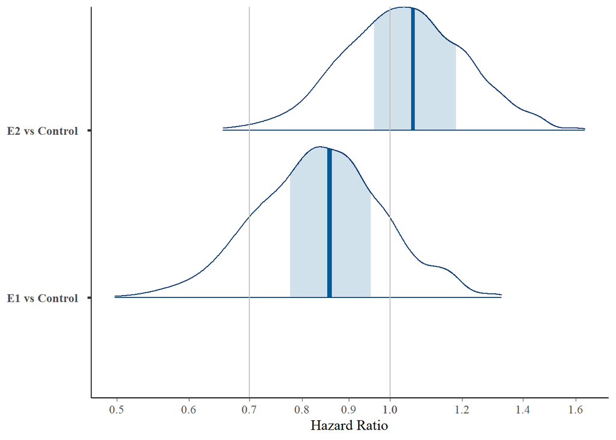

```r
plot(fit, pars=effects, plotfun = "areas", transformations="exp")+
  labs(x="Hazard Ratio")+scale_y_discrete(labels=c("E1 vs Control  ","E2 vs Control  "))+
  scale_x_log10(breaks=c(seq(0.4,1,by=0.1),seq(1,3,by=0.2)))+geom_vline(xintercept=c(0.7,1), col="grey")
```

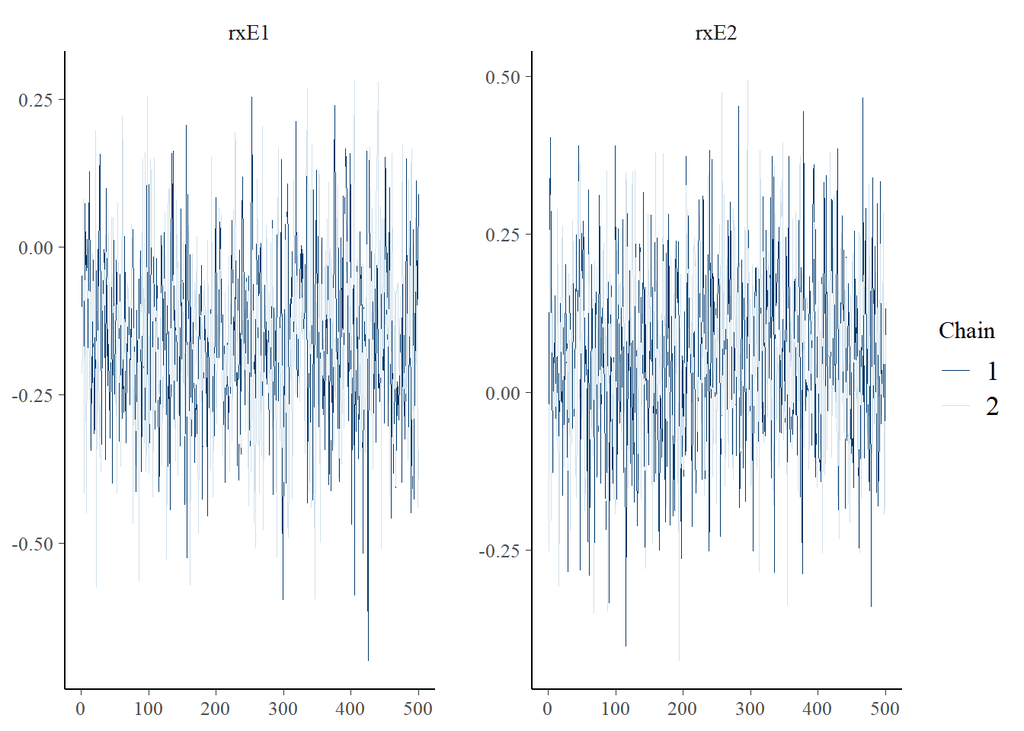

```r
#plot(fit, pars=effects, "hist")
#plot(fit, pars=effects, "violin")
#plot(fit, pars=effects, "dens_overlay")
plot(fit, pars=effects, "trace")
```

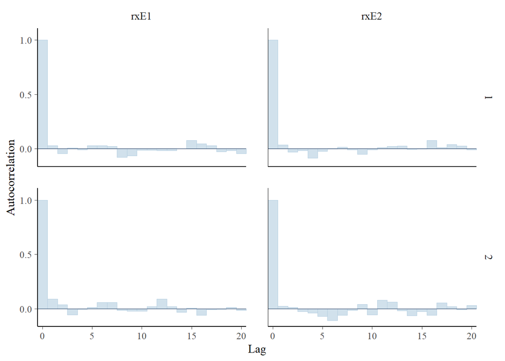

```r
plot(fit, pars=effects, "acf_bar")
```

```r
posterior <- as.array(fit)
#dimnames(posterior)

prob_interval <- function(X, interval){
  Y <- interval[1]< X & X <interval[2]
  mean(Y)
}
efficacy <- apply(posterior, 3, FUN=prob_interval, interval=c(-Inf, 0))[effects]
moderate_efficacy <- apply(posterior, 3, FUN=prob_interval, interval=c(-Inf, log(0.8)))[effects]
similarity <- apply(posterior, 3, FUN=prob_interval, interval= log(c(0.8,1.25)))[effects]
harm <- apply(posterior, 3, FUN=prob_interval, interval= c(0,Inf))[effects]
```

Reporting as per section 15.2 of the protocol to give the posterior probability of the HR lieing in various ranges of interest.

```r
X <- rbind(efficacy, moderate_efficacy, similarity, harm) %>% as.data.frame
X <- cbind(HR=c("<1","<0.8","0.8-1.25",">1"),X)
X %>% kable(row.names=FALSE, col.names=c("HR","E1 vs Control  ", "E2 vs Control  "))
```

| HR | E1 vs Control | E2 vs Control |
| --- | --- | --- |
| <1 | 0.841 | 0.351 |
| <0.8 | 0.313 | 0.029 |
| 0.8-1.25 | 0.681 | 0.834 |
| >1 | 0.159 | 0.649 |

# PRedictive Power Calculation

This consist of a few steps iterated thousands of times to generate future theoretical data and then averaged

- Simulate from the posteriro distribution of the model paraemters
- Use parameters to simulate failure times of future patients
- analyse current data + simulated and estimate treatment effects

For each data set we then use to consider only taken forwards a subset of the arms, and fixing the total sample size. The final analysis is performed using CoxPH (using a Bayesian MCMC version at this point would take a very long time to compute for a simulation ). Each simulation is thus declared to have show a statistically significant difference (one-side alpha=0.025). We average across teh simulatinos to caclulate the predictive power.

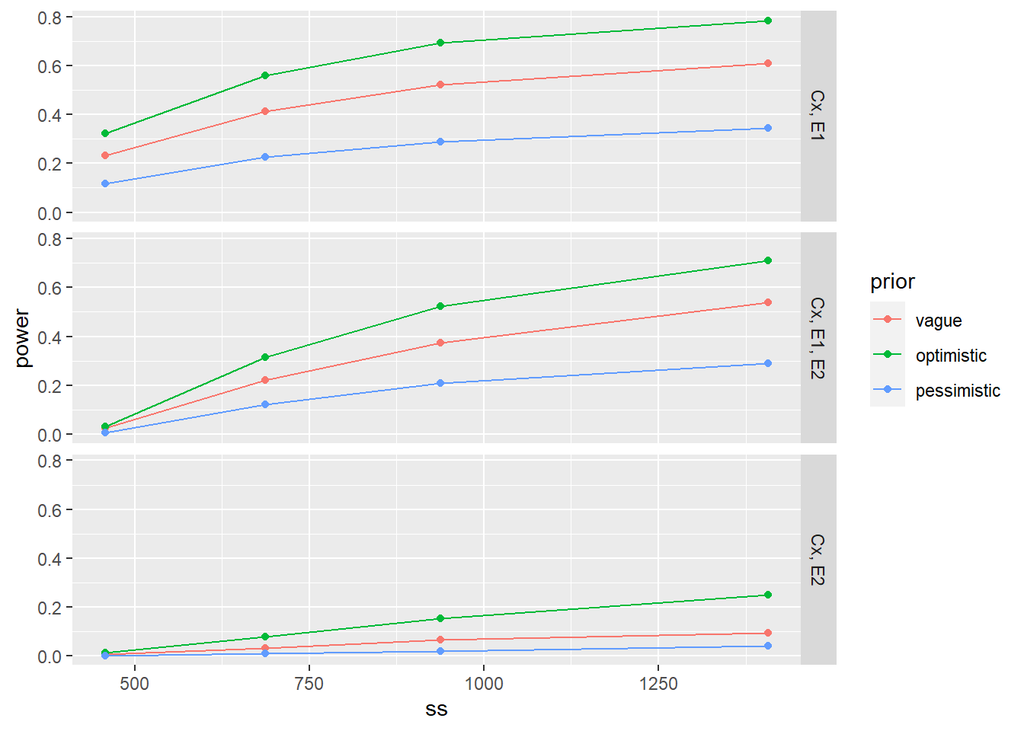

```r
n_new <- 1500
#Generate data for posterior_predict(newdata)

#Bootstrap from the original data the desired nunmber of times

#n_new is defined globally
if(!exists("n_new")){warning("setting n_new to 200"); n_new <- 200}

df_new <- df[sample(1:nrow(df), n_new, replace=TRUE),]
#summary(df_new)
#force the randomisation argument to be an equal split seperate from teh original data
n <- nrow(df_new)
n_arms <- nlevels(df_new$rx)
n_per_arm <- n%/%n_arms
spare <- n%%n_arms
df_new$rx <- factor(c(rep(1:n_arms, n_per_arm),rep(1,spare)), labels=levels(df$rx))
df_new$id <- 1:nrow(df_new)
#convert to long format with a row for each day
long <- expand.grid(time=sort(fail_times), id=df_new$id)
df_new_long <- left_join(long, df_new %>% select(-time), by="id")


# FUnction to add back in a simulated status endppoint
# and convert to standard survival data : either long counting, or short time/status

add_sim_status <- function(df, posterior,...){
  # ... give the covariates to keep.
  ##  future_analysis doesn't pass this on directly at the moment

  require(dplyr)
  require(magrittr)
  # this works one row at a time for posterior
  df$status <- posterior
 df_fail_time <- df %>%  group_by(id) %>%
    filter(status>0) %>% summarise( fail_time=min(time))
 # Say you had a  discrete survival distribution to simulate from
 # geenrate a U(0,1) and then invert the CDF
 # grouping together the poisson outcomes >=1, does this in effect
 # a value >1 means the precise failure occured earlier, but within that interval.


  df_long<- left_join(df, df_fail_time, by=c("id"="id")) %>%
    mutate( fail_time=ifelse(is.na(fail_time),Inf, fail_time)) %>%
    filter( time<=fail_time)


    covars <- c(quos(id,rx), quos(...))

  df_short <- df_long %>% group_by(!!!covars) %>%
    summarise(time=max(time), status=min(1,max(status)))
  list("long"=df_long, "short"=df_short)
}
#test
if(FALSE){
  ans <- add_sim_status(df_new_long , pred_data[6,],"rx")
  plot(survfit(Surv(time, status)~rx, data=ans$short))
  plot(survfit(Surv(time, status)~rx, data=df))
  df %>% group_by(rx) %>% summarise(event=mean(status))
  ans$short %>% group_by(rx) %>% summarise(event=mean(status))
  mean(df$status)
  mean(ans$short$status)
}




### Now add back in censoring ...


# Generate a censoring distribution survfit(Surv(time, 1- status)~1).
censor_dist <- survfit(Surv(time, 1-status)~1, data=df)
time <- censor_dist$time
S <- censor_dist$surv
p <- -diff(c(1,S))
index <- which(p!=0)
censor_dist <- data.frame(time=time[index], prob=p[index])
# But add in an admin censor at the end if needed - might vary between patients if we have calendar censoring.
admin_cens <- 15
# make this the last day+1
# the rule will be that censoring wins for ties
# so this allows people to fail on day 14, rather than being censored - if they get day 15
early <- subset(censor_dist, time <admin_cens)
prob_cens <- sum(early$prob)
censor_dist <- rbind( early,
       c(admin_cens, 1-prob_cens)
)

add_censor_sample <- function(data, censor_dist){
  n <- nrow(data)
  data$censor_time <- sample(censor_dist$time, n, replace=TRUE, prob=censor_dist$prob)
  data <- mutate(data,
                 time=pmin(time, censor_time),
                 status=ifelse(censor_time<=time, 0, status)
                 )
  data
}
#test
if(FALSE){
  survfit(Surv(time, status)~rx, data=ans$short) %>% plot(mark.time=TRUE)
  ans2 <- add_censor_sample(ans$short, censor_dist)
  survfit(Surv(time, status)~rx, data=ans2) %>% plot(mark.time=TRUE)
}
# this gets us output : df_new_long, censor_dist,  several functions add_*()
# For each row of pred_Data
future_analysis <- function(prediction, newdata, olddata,
                            arms=NULL,
                            n_total=nrow(newdata)+nrow(olddata),
                            parallel=TRUE){
  # add_sim_stats()
  require(doParallel)
  require(foreach)


  #prediction <- pred_data[1,]# FUN=future_analysis,
  #newdata=df_new_long
  #o#lddata=df

  df_new <- add_sim_status(newdata, prediction,rx,site)
  # add_censor_sample()
  df_new <- add_censor_sample(df_new$short, censor_dist)
  # combine with the original data
  common_names <- intersect(names(df_new), names(olddata))
  df_all <- rbind(olddata %>% as.data.frame %>%  select(all_of(common_names)),
                  df_new %>% as.data.frame %>%  select(all_of(common_names))
  )
  n_arms <- length(arms)
  if(!is.null(arms)){
    df_all <- subset(df_all, rx %in% arms)
    #n_arms <- nlevels(olddata$rx)
  }
  if( min(n_total)<nrow(olddata)*n_arms/nlevels(olddata$rx)){
    stop("you are throwing out the existing data!")
  }

  if(!parallel){
  ans <- array(NA, c(length(n_total), 2*(n_arms-1)))
  for( row in 1:length(n_total)){
    df_subset <- df_all[1:n_total[row],]
    df_subset$rx <- droplevels(df_subset$rx)
    # consider which arms to use, how many new patients.
    # calculate coefs and SE using coxph - but leave open to stan_glm()...
    analysis <- coxph(Surv(time,status)~rx+frailty.gaussian(site), data=df_subset)
    # loop across rows and then calculate OCs: power, bias, SE, coverage...
    se <- analysis$var %>% diag %>% sqrt
    ans[row,] <- c(analysis$coefficients, se)
  }
  }

  if(parallel){
  #cl<-makeCluster(2)
  #registerDoSNOW(cl)
  ans <- foreach( row = 1:length(n_total), .packages = c("survival","magrittr"),
                   .combine=rbind, .export=c("df_all","n_total"), .inorder=TRUE
                   )  %dopar% {
    df_subset <- df_all[1:n_total[row],]
    df_subset$rx <- droplevels(df_subset$rx)
    # consider which arms to use, how many new patients.
    # calculate coefs and SE using coxph - but leave open to stan_glm()...
    analysis <- coxph(Surv(time,status)~rx+frailty.gaussian(site), data=df_subset)
    # loop across rows and then calculate OCs: power, bias, SE, coverage...
    se <- analysis$var %>% diag %>% sqrt
    c(analysis$coefficients, se)
  }
  #stopCluster(cl)
  }
  ans
}



combinations <- function(x){
  m <- length(x)
  n <- 2^m
  ans <- vector("list",n-1)
  for(i in 1:(n-1)){
    index <- binary(i)
    pad <- m-length(index)
    index <- c(as.logical(index),rep(FALSE,pad))
    ans[[i]] <- x[index]
  }
  ans
}

#combinations(c("A","B","C"))

binary <- function(x){
  if(x<2){
    return(x)
  }else{
    alpha <- x %% 2
    x <- x %/% 2
    return( c(alpha, Recall(x)))
  }
}

#as.logical(binary(4))


power <- function(arms,n_total){
  require(doParallel)
  require(foreach)
  # apply doesn't respect the array structure returned by future_analysis()
  #oc_data <- array(NA, dim = c(dim(pred_data)[1], length(n_total), 2*(length(arms)-1)))


#  for(row in 1:dim(oc_data)[1])

  oc_data_list <- foreach( row = 1:dim(pred_data)[1],
                      .export=c("future_analysis","pred_data","df_new_long",
                                #"arms","n_total",
                                "df","add_sim_status","add_censor_sample",
                                "censor_dist"),
                      .inorder=FALSE,
                      .packages=c("survival","magrittr")) %dopar%
  {
   future_analysis(
     pred_data[row,],newdata=df_new_long, olddata=df,
     arms=arms, n_total=n_total
   )
  }
  #stopCluster(cl)
  #oc_data <- simplify2array(oc_data_list)
  # for(row in 1:dim(oc_data)[1]){
  #   oc_data[row, ,] <-  oc_list[[ row]]
  #
  #   # future_analysis(
  #   #   pred_data[row,],newdata=df_new_long, olddata=df,
  #   #   arms=arms, n_total=n_total
  #   # )
  # }
  #


  if( length(arms)==3){
    z1 <- sapply(oc_data_list,  FUN = function(x){x[,1]/x[,3]}, simplify="array") #oc_data[,1,]/oc_data[,3,]
    z2 <-  sapply(oc_data_list,  FUN = function(x){x[,2]/x[,4]}, simplify="array")#oc_data[,2,]/oc_data[,4,]
  } else{
    z1 <- z2 <- sapply(oc_data_list,  FUN = function(x){x[,1]/x[,2]}, simplify="array")#oc_data[,1,]/oc_data[,2,]
  }

  #1-side alpah/2 test
  any_result <- (pnorm(z1)<0.025) |(pnorm(z2)<0.025)
  power <- apply(any_result,1, mean)
  #apply(pnorm(z1)<0.025,2, mean)
  #apply(pnorm(z2)<0.025,2, mean)
  return(power)
}
#creates some functions.

power_df <- data.frame(power=numeric(0),
                    ss=numeric(0),
                    arms=character(0),
                    prior=character(0)
                  )
for( index in 1:length(fits)){
  #index <- 1
  fit <- fits[[index]]
  pred_data <- posterior_predict(fit, newdata = df_new_long)
      # all possible combination of arms, with Cx allways taken forwards
  arms <- combinations(levels(df$rx)[-1])
  arms <- lapply(arms, function(x){c("Cx",x)})
  ref_ss <- c(458,687,938,1407)
  #ans <- power(arms[[3]], n_total = ref_ss)
  power_list <- lapply(arms, power, n_total=ref_ss)
  arms_char <- sapply(arms, paste, collapse=", ")
  power_df <- rbind(power_df,
                    data.frame(power=unlist(power_list),
                               ss=rep(ref_ss, length(arms)),
                               arms=rep(arms_char, rep(length(ref_ss),length(arms))),
                               prior=names(fits)[index]
                    )
  )
}

ggplot(power_df, aes(x=ss,y=power, group=prior, colour=prior))+
  geom_line()+geom_point()+facet_grid(arms~.)
```

```r
stopCluster(cl)
```

# Todo List

- Look into setting the prior for the random effects “better”.
- Futher look into options for parallelisation: gpu and [HPC docs](https://docs.hpc.cam.ac.uk/)
- consider nesting of foreach() %:%
- put in some timing metric
- Embed in a simulation with decision rules applied and new data generated
- Vary the scenarios of the true data generating process